# Estimating Value-at-Risk of a Portfolio with GARCH-family Models

Andrei Shelest, Zofia Bracha

2024-07-04

```r
suppressMessages({
  suppressWarnings({
    library(tidyverse)
    library(xts)
    library(fBasics)
    library(tseries)
    library(car)
    library(FinTS)
    library(rugarch)
    library(quantmod)
    library(hash)
    library(foreach)
    library(doParallel)
  })
})
```

- Everywhere here significance is assumed at p=0.05, if not said otherwise.
- LB - Ljung-Box test
- LM - Lagrange multipliers test

# Components of Portfolio

For the purposes of the project, the following instruments have been used.

- Equity index: S&P500 (^SPX)
- Company stock: Dell Technologies Inc. (DELL)
- Currency pair: EUR/USD (EURUSD=X)
- Brent Crude Oil (BZ=F)
- Ethereum USD (ETH-USD)

Data is downloaded from Yahoo Finance, for the period from 2019-01-01 to 2023-12-31.

```r
tickers <- c("^SPX", "DELL", "EURUSD", "BZ=F", "ETH-USD")

date_from <- "2019-01-01"
date_to <- "2023-12-31"

download_data <- FALSE

if(download_data){
  for(ticker in tickers){
    if(ticker == "EURUSD") {
      next # downloaded from stooq instead, because of apparent incorrect dates in yahoo for EUR/USD
    }
    ticker_data <- getSymbols(Symbols = ticker,
             from = date_from,
             to = date_to,
             src="yahoo",
             auto.assign = FALSE)
    act_ticker <- gsub("^\\^", "", ticker)
    adj_ticker <- sprintf("%s.Adjusted", act_ticker)

    ticker_df <- data.frame(Date=index(ticker_data), Adjusted=ticker_data[, adj_ticker])
    names(ticker_df)[2] <- "Adjusted"

    write.csv(ticker_df, sprintf("./data/%s.csv", ticker), row.names=FALSE)
  }
}
```

```r
plot_quotes = function(df, quote_col, title){
  if(has_name(df, "Date"))
  {
      df_xts <- xts(df[, quote_col], order.by=df$Date)
  }
  else{
    df_xts <- xts(df[, quote_col], order.by=as.Date(rownames(df)))
  }
  plot(df_xts[,1],
     main = title,
     col = "red",
     major.ticks = "years",
     grid.ticks.on = "years",
     grid.ticks.lty = 3,
     lwd = 2,
     cex = 0.5)
}
```

## Prelimnary Analysis - Quotes and Returns

```r
tickers_map = hash()
joined_returns = NULL

lr_label = function(ticker){
  return(sprintf("%s.r", ticker))
}


for(ticker in tickers){
  ticker_df <- read.csv(sprintf("./data/%s.csv", ticker), header=TRUE)
  ticker_df$Date <- as.Date(ticker_df$Date)

  r_label <- lr_label(ticker)

  ticker_df[[r_label]] <- diff.xts(log(ticker_df$Adjusted)) # log return

  tickers_map[[ticker]] <- ticker_df

  if(is.null(joined_returns)) {
    joined_returns <- ticker_df %>% select(Date, `r_label`)
  }
  else {
    joined_returns <- full_join(joined_returns, ticker_df %>% select(Date, `r_label`))
  }

}

joined_returns <- joined_returns %>% arrange(Date)
```

### S&P500

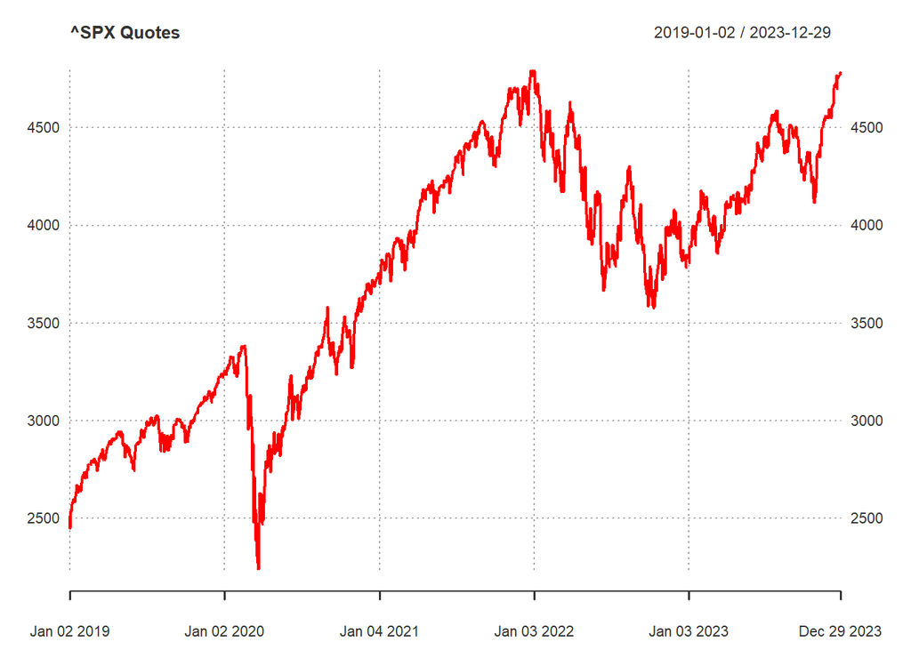

```r
plot_quotes(tickers_map[[tickers[1]]], "Adjusted", sprintf("%s Quotes", tickers[1]))
```

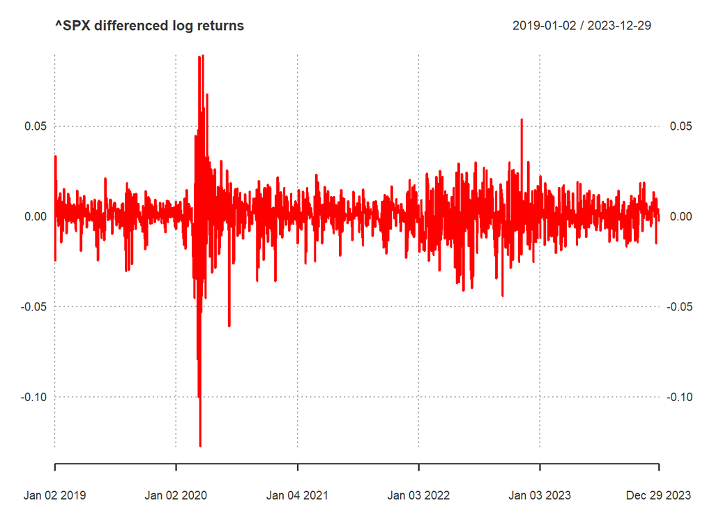

```r
plot_quotes(tickers_map[[tickers[1]]], lr_label(tickers[1]), sprintf("%s differenced log returns", tickers[1]))
```

We observe huge volatility clustering around 2020 market crash and in 2022 during bearish market.

### Dell

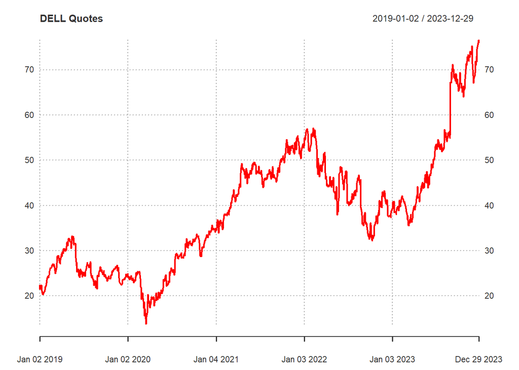

```r
plot_quotes(tickers_map[[tickers[2]]], "Adjusted", sprintf("%s Quotes", tickers[2]))
```

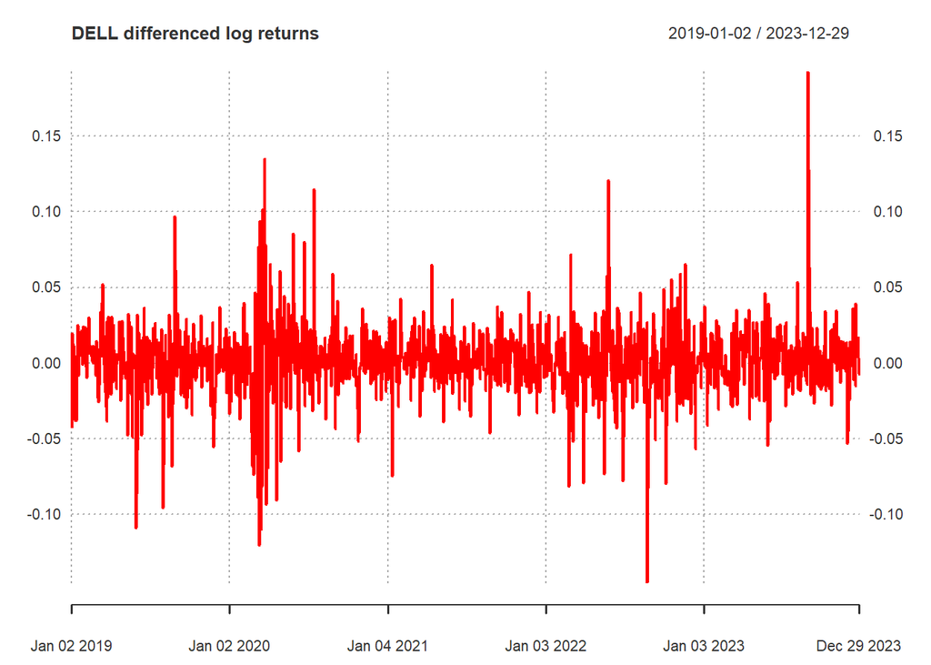

```r
plot_quotes(tickers_map[[tickers[2]]], lr_label(tickers[2]), sprintf("%s differenced log returns", tickers[2]))
```

Here the 2020 volatility cluster is more pronounced than of 2022.

### EUR/USD

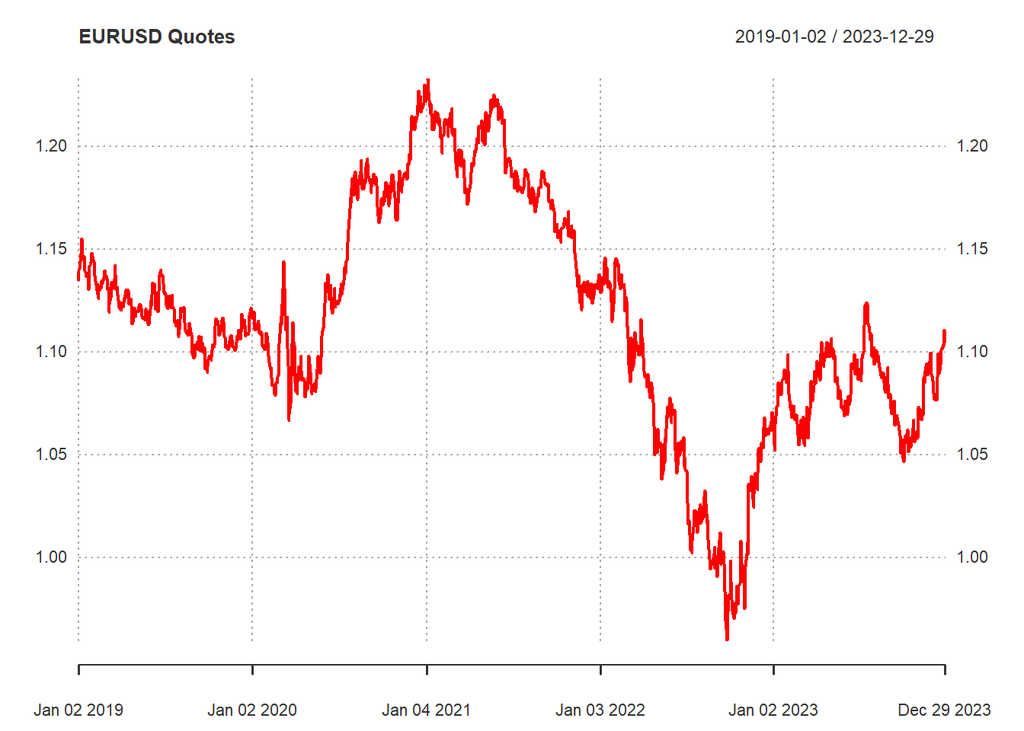

```r
plot_quotes(tickers_map[[tickers[3]]], "Adjusted", sprintf("%s Quotes", tickers[3]))
```

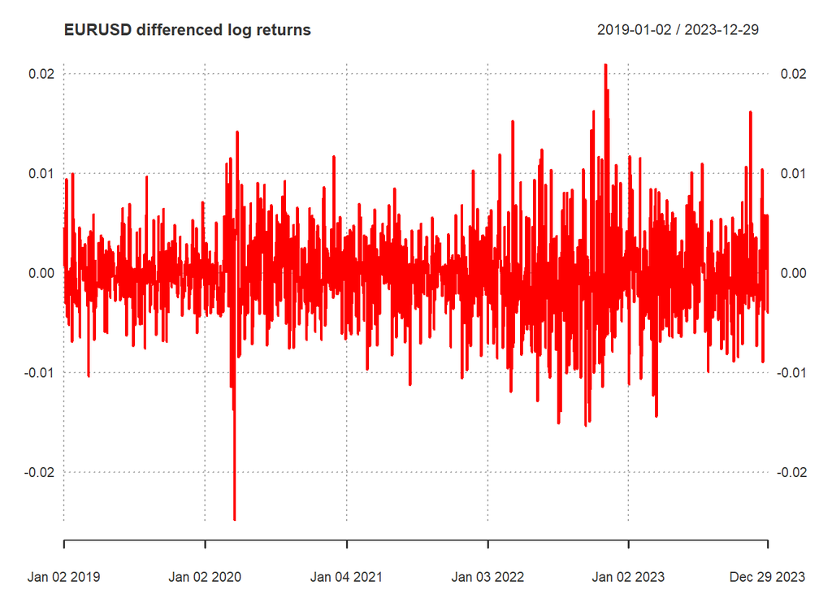

```r
plot_quotes(tickers_map[[tickers[3]]], lr_label(tickers[3]), sprintf("%s differenced log returns", tickers[3]))
```

For EUR/USD volatility cluster is visible for 2022.

### Brent

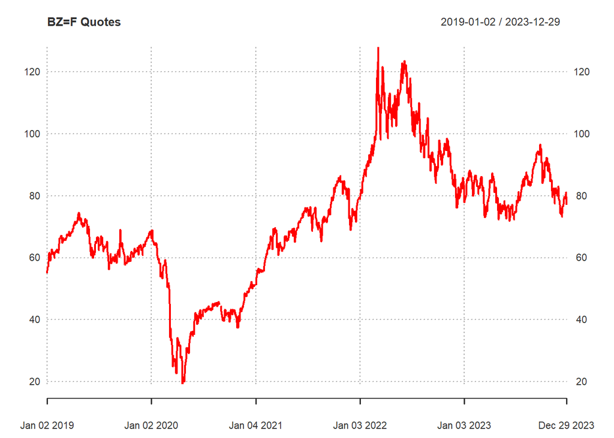

```r
plot_quotes(tickers_map[[tickers[4]]], "Adjusted", sprintf("%s Quotes", tickers[4]))
```

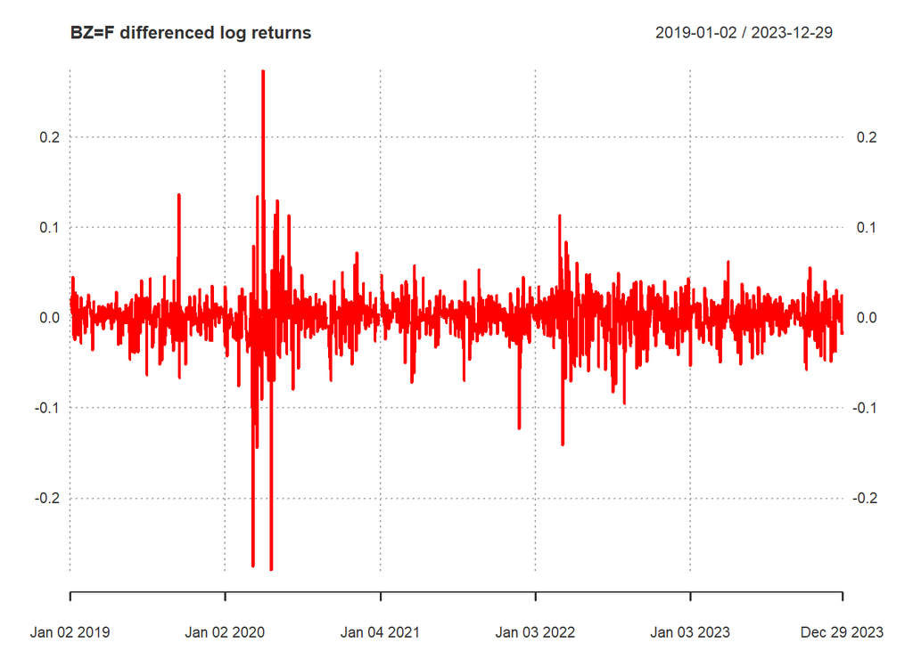

```r
plot_quotes(tickers_map[[tickers[4]]], lr_label(tickers[4]), sprintf("%s differenced log returns", tickers[4]))
```

For Brent Crude Oil volatility clustering is observed in 2020 in 2022.

### Ethereum

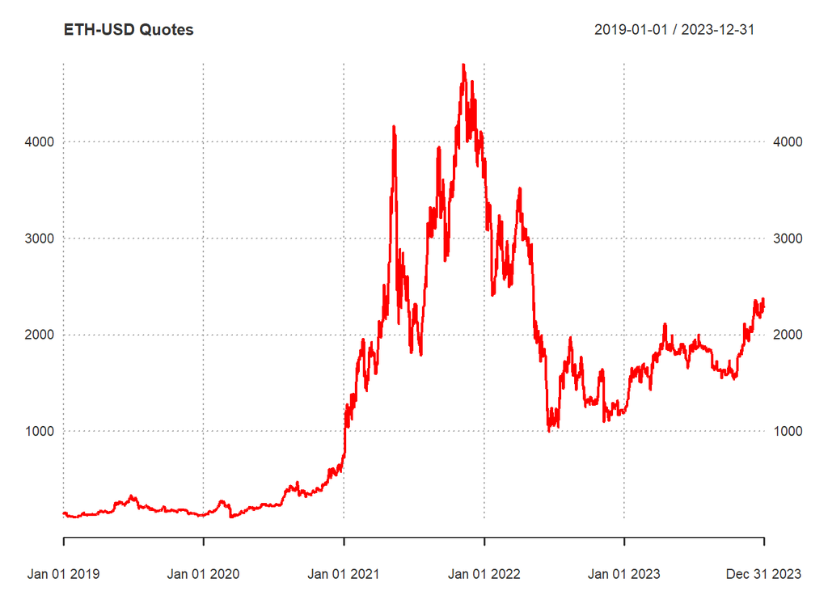

```r
plot_quotes(tickers_map[[tickers[5]]], "Adjusted", sprintf("%s Quotes", tickers[5]))
```

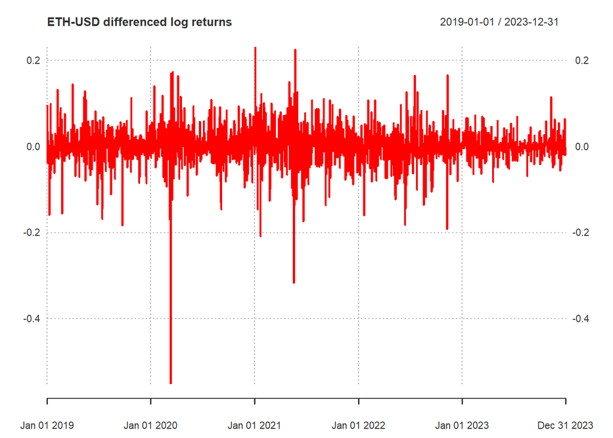

```r
plot_quotes(tickers_map[[tickers[5]]], lr_label(tickers[5]), sprintf("%s differenced log returns", tickers[5]))
```

Not only does Ethereum have a volatility cluster around 2020 crash, but also it has volatility clustering in 2021, the era of meme stocks and coins. Obviously, it is even better visible on quotes chart.

## Portfolio

### Constructing Joint Log Returns

Here the important decision is whether to trade or not to trade on weekends and bank holidays. Since only Ethereum is traded all the time, we decide to trade only on working days. The alternative option is to replace all non-trading day returns with zeros, but this solution will reduce the overall variance of returns.

The list of non trading days was generated by ChatGPT-4o prompt “I need a list of weekend days and bank holidays for US since 2015 till 2025 in CSV file, column named Date, dates in format YYYY-mm-dd”.

```r
non_trading_days <- read.csv("./data/non_trading_days.csv", header=TRUE)

joined_returns <- joined_returns %>% filter(! Date %in% non_trading_days$Date) %>% slice(-1)
print(sprintf("NAs left: %i", sum(is.na(joined_returns))))
```

```
## [1] "NAs left: 26"
```

The rest of the possible missing returns we are replacing with zeros.

```r
joined_returns <- joined_returns %>% replace(is.na(.), 0)
```

Now let’s calculate the log-return of portfolio ($w_i=w=1/N$, $R$ stands for arithmetic return, $r$ - for logarithmic return).

$$ln \dfrac{\Pi_{t+1}}{\Pi_{t}} =
ln\dfrac{\sum_{i=1}^{N}S_{i,t+1}}{\Pi_t}=ln\dfrac{1/N\,\sum_{i=1}^{N}\Pi_{t}R_{i,t+1}}{\Pi_t}
= ln \dfrac{1}{N}\sum_{i=1}^{N}R_{i,t+1} = ln
\dfrac{1}{N}\sum_{i=1}^{N}e^{r_{i,t+1}}$$

```r
ret_sum <- numeric(length(joined_returns))

for(ticker in tickers){
  ret_sum <- ret_sum + exp(joined_returns[, lr_label(ticker)])
}

joined_returns$r <- log(1/length(tickers) * ret_sum)
```

```r
head(joined_returns, n=10)
```

```
##          Date        ^SPX.r       DELL.r      EURUSD.r       BZ=F.r
## 1  2019-01-03 -0.0250683318 -0.043150335  0.0045213521  0.018762970
## 2  2019-01-04  0.0337593991  0.019528886  0.0007808080  0.019644921
## 3  2019-01-07  0.0069859760  0.006497645  0.0063727613  0.004720709
## 4  2019-01-08  0.0096485873  0.011804020 -0.0030283351  0.023956326
## 5  2019-01-09  0.0040896713  0.001492599  0.0094300108  0.045280661
## 6  2019-01-10  0.0045082414 -0.037994597 -0.0044255539  0.003898668
## 7  2019-01-11 -0.0001463085 -0.016060959 -0.0030397940 -0.019647010
## 8  2019-01-14 -0.0052713946 -0.038276595  0.0001918934 -0.024944758
## 9  2019-01-15  0.0106646189  0.004894521 -0.0052028571  0.027586765
## 10 2019-01-16  0.0022195205 -0.009109192 -0.0009823959  0.011151318
##       ETH-USD.r            r
## 1  -0.038880705 -0.016465251
## 2   0.035872308  0.021996354
## 3  -0.039087680 -0.002739629
## 4  -0.008869749  0.006769147
## 5   0.002945130  0.012785383
## 6  -0.159072500 -0.036734198
## 7  -0.008407309 -0.009432643
## 8   0.099044934  0.007345116
## 9  -0.056055856 -0.003226000
## 10  0.012333019  0.003154091
```

```r
tail(joined_returns, n=10)
```

```
##            Date        ^SPX.r       DELL.r      EURUSD.r        BZ=F.r
## 1241 2023-12-15 -0.0000762524 -0.011246143 -0.0089186767 -0.0007834625
## 1242 2023-12-18  0.0045181223  0.024140748  0.0025667836  0.0181233944
## 1243 2023-12-19  0.0058492675  0.002178315  0.0055783184  0.0162875010
## 1244 2023-12-20 -0.0147931480 -0.015211012 -0.0036575451  0.0059144902
## 1245 2023-12-21  0.0102487693  0.039263176  0.0058765549 -0.0038971395
## 1246 2023-12-22  0.0016586822  0.005164592  0.0004177868 -0.0040388758
## 1247 2023-12-26  0.0042227610  0.016895194  0.0026117489  0.0249794430
## 1248 2023-12-27  0.0014294356  0.003370963  0.0058246016 -0.0176709197
## 1249 2023-12-28  0.0003701061 -0.007535394 -0.0039425717 -0.0159456951
## 1250 2023-12-29 -0.0028304770 -0.002350274 -0.0019273146 -0.0173715810
##         ETH-USD.r            r
## 1241 -0.042882888 -0.012659391
## 1242  0.009421634  0.011787790
## 1243 -0.017929750  0.002455363
## 1244  0.010977281 -0.003297686
## 1245  0.016945804  0.013792471
## 1246  0.038104101  0.008377714
## 1247 -0.018249258  0.006199915
## 1248  0.063912462  0.011757031
## 1249 -0.013191816 -0.008031391
## 1250 -0.020169745 -0.008897205
```

### Plots of the log-returns.

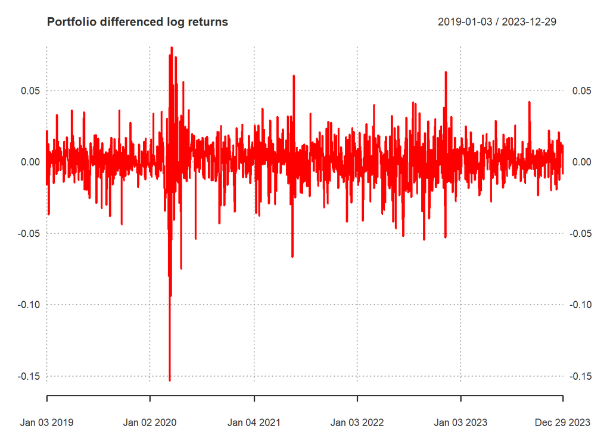

```r
plot_quotes(joined_returns, "r", "Portfolio differenced log returns")
```

There is a clear volatility cluster at the beginning of 2020, as well as smaller clusters in the middle of 2021 and 2022.

### ACF plots for log returns and square log returns.

```r
plot_acf = function(values, max_lim, title){
  acf(values, lag.max = 36, na.action = na.pass,
    ylim = c(-0.2, max_lim), col = "darkblue", lwd = 4,
    main = title)
}
```

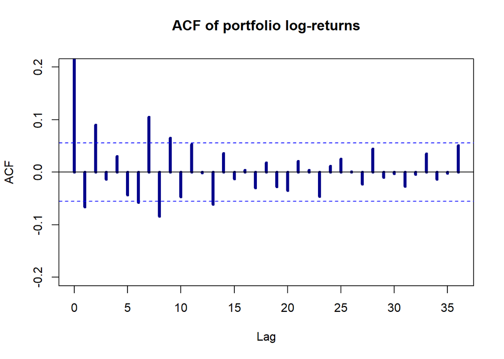

```r
plot_acf(joined_returns$r, 0.2, "ACF of portfolio log-returns")
```

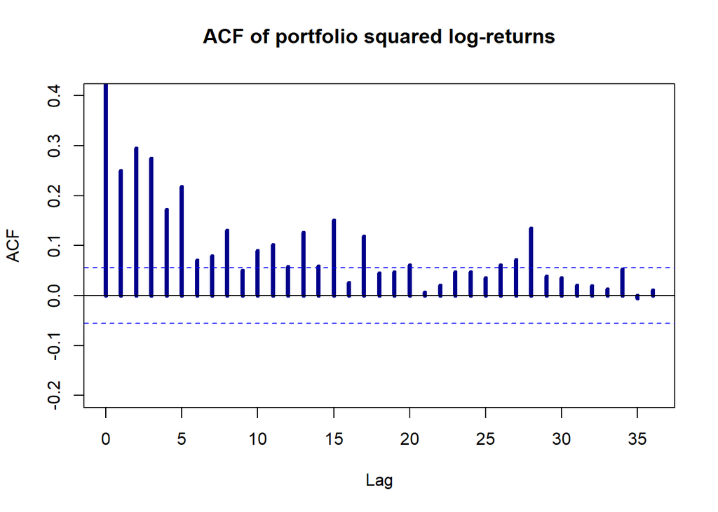

```r
plot_acf(joined_returns$r^2, 0.4, "ACF of portfolio squared log-returns")
```

Observations:

- There are a couple of lags for plain log-returns.
- On the other hand, there are significant ACF values for lags for squared log-returns, hence we can assume the presence of serial autocorrelation.

## Formal Testing for ARCH effects

### Heteroscedasticity of Residuals

```r
ArchTest(joined_returns$r, lags=10)
```

```
##
##  ARCH LM-test; Null hypothesis: no ARCH effects
##
## data:  joined_returns$r
## Chi-squared = 207.2, df = 10, p-value < 2.2e-16
```

LM test strongly rejects null hypothesis of homoscedasticity of log-returns and no autocorrelation of squared log-returns.

```r
Box.test(resid(lm(joined_returns$r ~ 1)), type = "Ljung-Box", lag = 10)
```

```
##
##  Box-Ljung test
##
## data:  resid(lm(joined_returns$r ~ 1))
## X-squared = 54.145, df = 10, p-value = 0.0000000456
```

```r
Box.test(resid(lm(joined_returns$r^2 ~ 1)), type = "Ljung-Box", lag = 10)
```

```
##
##  Box-Ljung test
##
## data:  resid(lm(joined_returns$r^2 ~ 1))
## X-squared = 427.55, df = 10, p-value < 2.2e-16
```

Ljung-Box test also strongly rejects the hypothesis of no autocorrelation both in simple and squared log-returns.

### Leptokurtosis

```r
jarque.bera.test(joined_returns$r)
```

```
##
##  Jarque Bera Test
##
## data:  joined_returns$r
## X-squared = 6012.8, df = 2, p-value < 2.2e-16
```

Based on Jarque-Bera test and its very small p-value, we strongly reject hypothesis of log-returns following normal distribution.

```r
basicStats(joined_returns$r)
```

```
##             X..joined_returns.r
## nobs                1250.000000
## NAs                    0.000000
## Minimum               -0.153473
## Maximum                0.080825
## 1. Quartile           -0.007200
## 3. Quartile            0.008847
## Mean                   0.000819
## Median                 0.001406
## Sum                    1.023538
## SE Mean                0.000451
## LCL Mean              -0.000065
## UCL Mean               0.001703
## Variance               0.000254
## Stdev                  0.015930
## Skewness              -0.942978
## Kurtosis              10.555668
```

The distribution of log-returns is left-skewed and has high kurtosis.

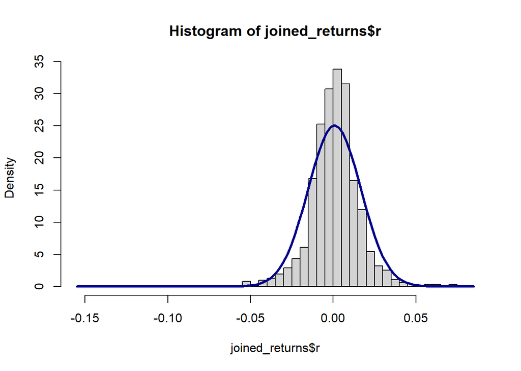

```r
hist(joined_returns$r, prob = TRUE, breaks = 50)
curve(dnorm(x, mean = mean(joined_returns$r), sd  = sd(joined_returns$r)),
            col = "darkblue", lwd = 3, add = TRUE)
```

We see more pronounced left tail and high kurtosis.

The overall conclusion is that there are ARCH effects present in the log-returns of the portfolio.

# Modelling

```r
insample_r <- joined_returns %>% filter(Date < as.Date('2023-01-01'))
```

```r
fit_garch = function(returns, arma_p, arma_q, arch_q, garch_p, model_type = "sGARCH", submodel = NULL){

  if(!is.null(submodel) && model_type == "fGARCH"){
    variance_model = list(model = model_type,
                          submodel = submodel,
                          garchOrder = c(arch_q, garch_p))
  } else {
    variance_model = list(model = model_type,
                          garchOrder = c(arch_q, garch_p))
  }

  # Specify the GARCH model
  spec <- ugarchspec(
    variance.model = variance_model,
    mean.model = list(armaOrder = c(arma_p, arma_q), include.mean = TRUE),
    distribution.model = "norm")


  model <- ugarchfit(spec=spec, data=returns)
  return(model)
}
```

## Standard GARCH models

Let’s begin with fitting some standard GARCH models.

### ARMA(0,0)-GARCH(1,1)

Let’s begin with the simplest option of a constant mean equation and ARCH and GARCH orders of 1.

```r
plot_std_residuals = function(fit_model){
  plot(fit_model, which=10)
}
plot_std_sq_residuals = function(fit_model){
  plot(fit_model, which=11)
}
plot_conditional_sd = function(fit_model){
  plot(fit_model, which=3)
}
plot_news_impact_curve = function(fit_model) {
  plot(fit_model, which=12)
}
plot_r_std_density = function(fit_model){
  std_residuals = (fit_model@fit$residuals - mean(fit_model@fit$residuals)) / fit_model@fit$sigma

  hist(std_residuals, prob=TRUE, breaks=40)
  curve(dnorm(x, mean = mean(std_residuals), sd  = sd(std_residuals)),
            col = "darkblue", lwd = 3, add = TRUE)
}
```

```r
arma00garch11 <- fit_garch(insample_r$r, 0, 0, 1, 1)
arma00garch11
```

```
##
## *---------------------------------*
## *          GARCH Model Fit        *
## *---------------------------------*
##
## Conditional Variance Dynamics
## -----------------------------------
## GARCH Model  : sGARCH(1,1)
## Mean Model   : ARFIMA(0,0,0)
## Distribution : norm
##
## Optimal Parameters
## ------------------------------------
##         Estimate  Std. Error  t value Pr(>|t|)
## mu      0.001074    0.000454   2.3662 0.017974
## omega   0.000014    0.000001  10.7645 0.000000
## alpha1  0.097280    0.010913   8.9140 0.000000
## beta1   0.849749    0.014581  58.2793 0.000000
##
## Robust Standard Errors:
##         Estimate  Std. Error  t value Pr(>|t|)
## mu      0.001074    0.000492   2.1831 0.029026
## omega   0.000014    0.000003   4.7483 0.000002
## alpha1  0.097280    0.013328   7.2991 0.000000
## beta1   0.849749    0.024920  34.0994 0.000000
##
## LogLikelihood : 2760.58
##
## Information Criteria
## ------------------------------------
##
## Akaike       -5.5077
## Bayes        -5.4880
## Shibata      -5.5077
## Hannan-Quinn -5.5002
##
## Weighted Ljung-Box Test on Standardized Residuals
## ------------------------------------
##                         statistic p-value
## Lag[1]                     0.4662  0.4948
```

[output cut: 37 more lines]

```
## Negative Sign Bias   1.681 0.09308   *
## Positive Sign Bias   1.864 0.06255   *
## Joint Effect         7.045 0.07049   *
##
##
## Adjusted Pearson Goodness-of-Fit Test:
## ------------------------------------
##   group statistic p-value(g-1)
## 1    20     43.58   0.00108082
## 2    30     57.75   0.00116633
## 3    40     77.80   0.00021930
## 4    50     95.05   0.00008874
##
##
## Elapsed time : 0.309298
```

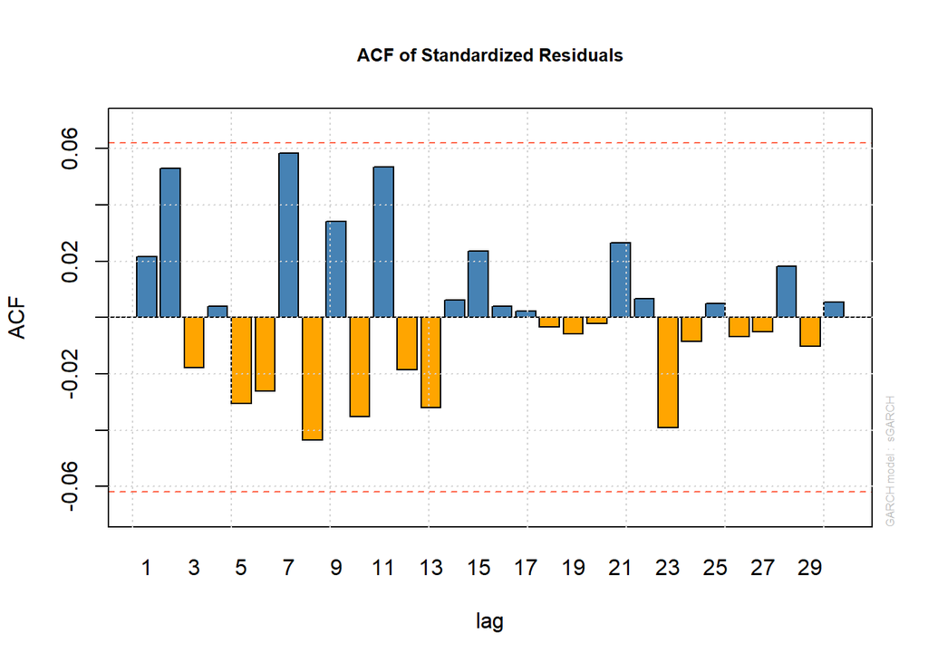

```r
plot_std_residuals(arma00garch11)
```

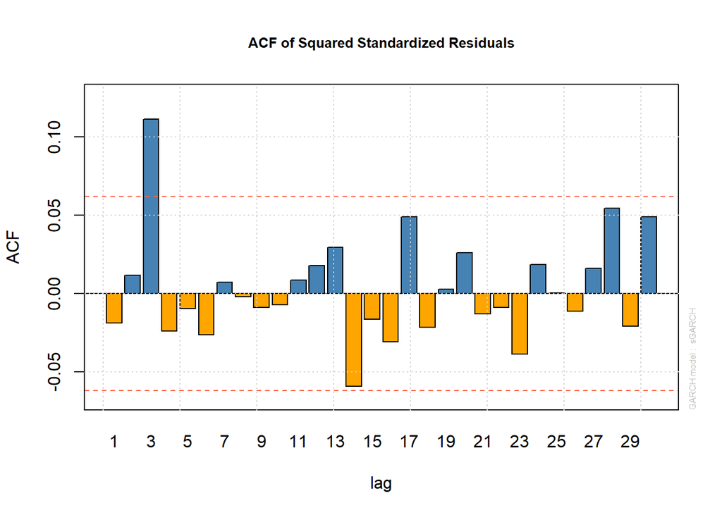

```r
plot_std_sq_residuals(arma00garch11)
```

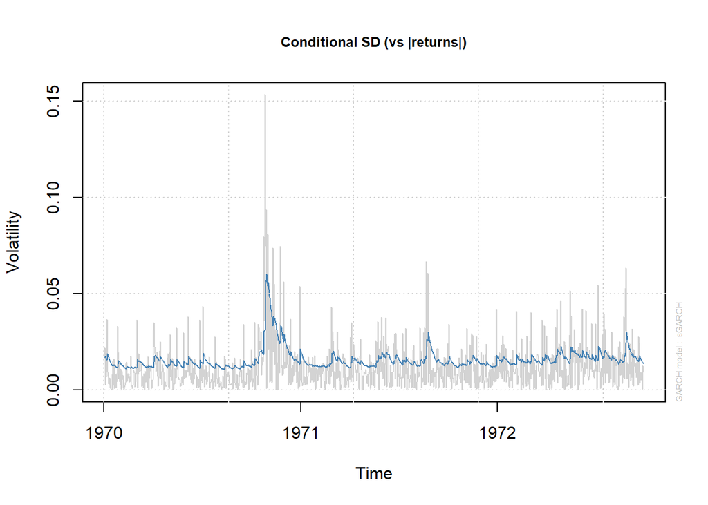

```r
plot_conditional_sd(arma00garch11)
```

#### Comment

- All the estimates or parameters are significant.
- ACF of standardized residuals shows no autocorrelation
- ACF of squared standardized residuals shows significant third lag.
- Both Ljung-Box test for standardized squared residuals and LM tests say that we reject null-hypothesis of no autocorrelation of said residuals, hence the model is not adequate.

### ARMA(0,0)-GARCH(2,1)

```r
arma00garch21 <- fit_garch(insample_r$r, 0, 0, 2, 1)
arma00garch21
```

```
##
## *---------------------------------*
## *          GARCH Model Fit        *
## *---------------------------------*
##
## Conditional Variance Dynamics
## -----------------------------------
## GARCH Model  : sGARCH(2,1)
## Mean Model   : ARFIMA(0,0,0)
## Distribution : norm
##
## Optimal Parameters
## ------------------------------------
##         Estimate  Std. Error  t value Pr(>|t|)
## mu      0.001093    0.000454   2.4068 0.016093
## omega   0.000017    0.000007   2.4021 0.016303
## alpha1  0.059986    0.032249   1.8601 0.062872
## alpha2  0.053556    0.036459   1.4689 0.141847
## beta1   0.822957    0.038129  21.5835 0.000000
##
## Robust Standard Errors:
##         Estimate  Std. Error  t value Pr(>|t|)
## mu      0.001093    0.000515  2.11982 0.034021
## omega   0.000017    0.000024  0.69768 0.485378
## alpha1  0.059986    0.048606  1.23413 0.217155
## alpha2  0.053556    0.055032  0.97318 0.330465
## beta1   0.822957    0.101610  8.09913 0.000000
##
## LogLikelihood : 2761.388
##
## Information Criteria
## ------------------------------------
##
## Akaike       -5.5073
## Bayes        -5.4827
## Shibata      -5.5073
## Hannan-Quinn -5.4980
##
## Weighted Ljung-Box Test on Standardized Residuals
## ------------------------------------
```

[output cut: 40 more lines]

```
## Negative Sign Bias   2.215 0.02702  **
## Positive Sign Bias   1.668 0.09561   *
## Joint Effect         8.566 0.03566  **
##
##
## Adjusted Pearson Goodness-of-Fit Test:
## ------------------------------------
##   group statistic p-value(g-1)
## 1    20     41.94    0.0018074
## 2    30     60.15    0.0005919
## 3    40     78.12    0.0002010
## 4    50     94.55    0.0001011
##
##
## Elapsed time : 0.300513
```

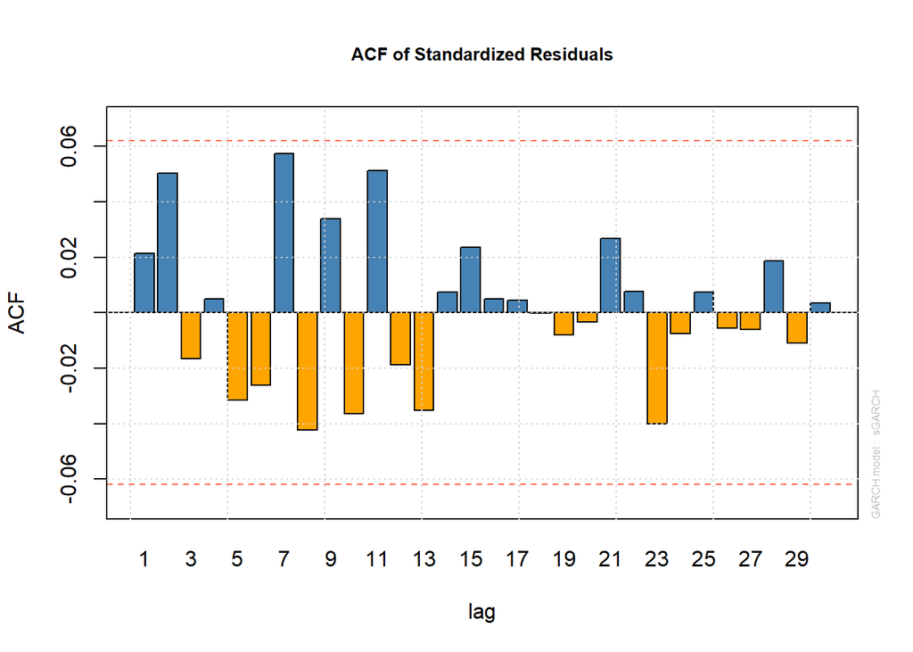

```r
plot_std_residuals(arma00garch21)
```

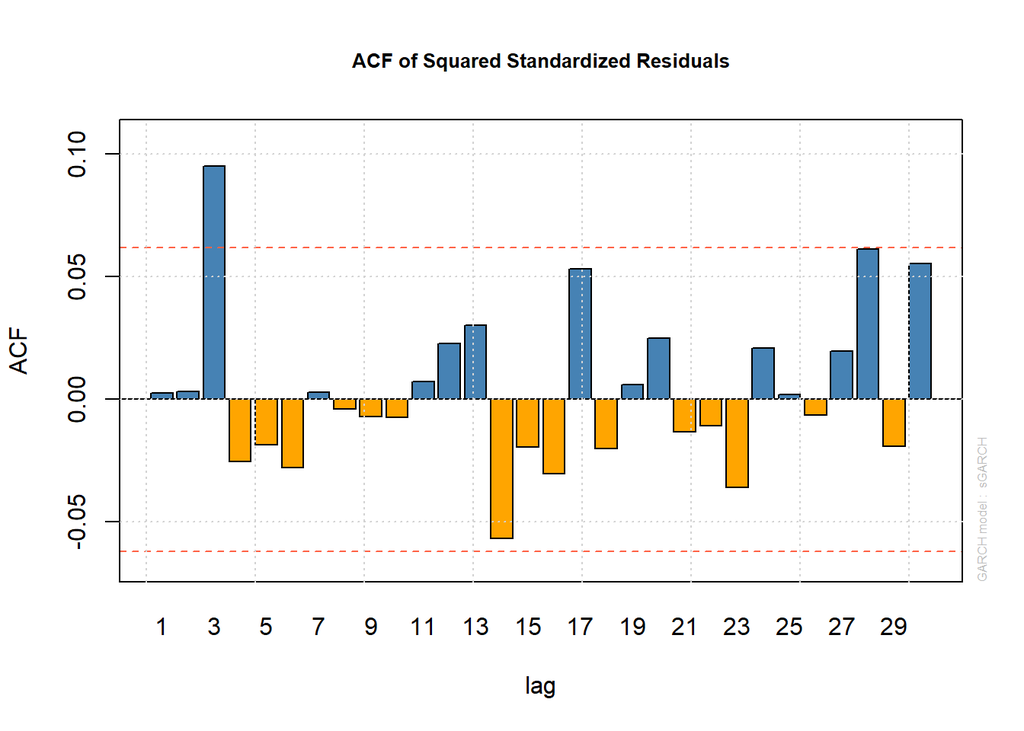

```r
plot_std_sq_residuals(arma00garch21)
```

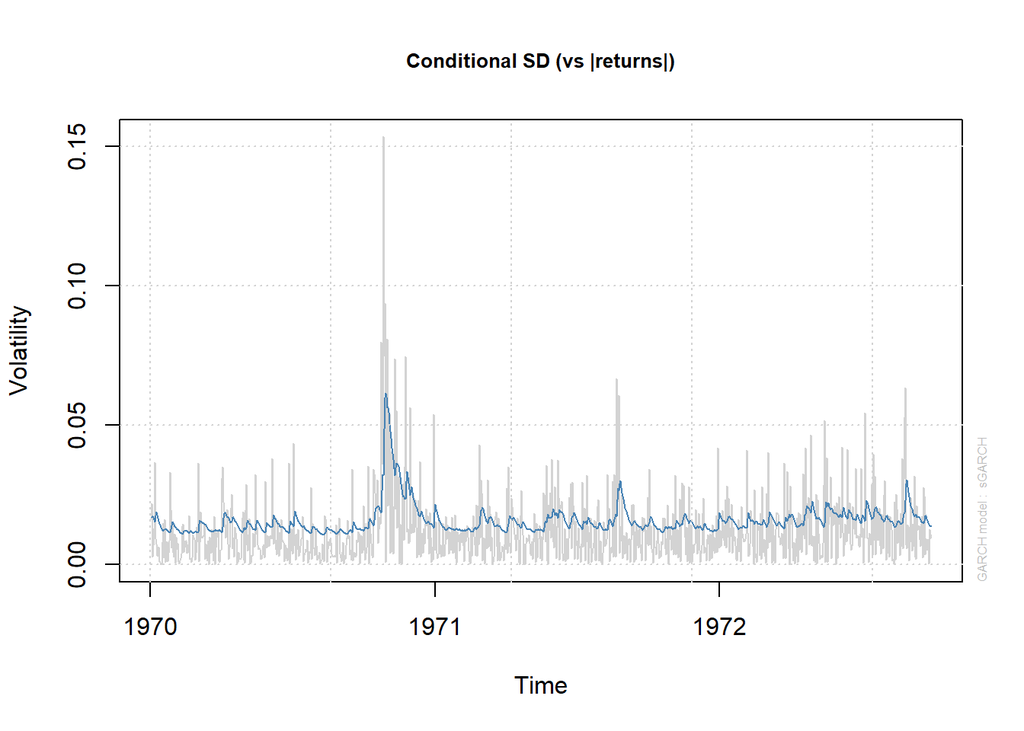

```r
plot_conditional_sd(arma00garch21)
```

#### Comment

- ARCH(1) and ARCH(2) parameters are insignificant.
- ACF of standardized residuals shows no autocorrelation.
- ACF of squared standardized residuals shows significant third lag. It is smaller than in ARCH(0,0)-GARCH(1,1).
- Both Ljung-Box test for standardized squared residuals and LM tests do not allow us to reject null-hypothesis of no autocorrelation of said residuals.

### ARMA(0,0)-GARCH(1,2)

```r
arma00garch12 <- fit_garch(insample_r$r, 0, 0, 1, 2)
arma00garch12
```

```
##
## *---------------------------------*
## *          GARCH Model Fit        *
## *---------------------------------*
##
## Conditional Variance Dynamics
## -----------------------------------
## GARCH Model  : sGARCH(1,2)
## Mean Model   : ARFIMA(0,0,0)
## Distribution : norm
##
## Optimal Parameters
## ------------------------------------
##         Estimate  Std. Error   t value Pr(>|t|)
## mu      0.001075    0.000455  2.365011 0.018030
## omega   0.000014    0.000001 13.821111 0.000000
## alpha1  0.097310    0.011384  8.547977 0.000000
## beta1   0.849753    0.230815  3.681528 0.000232
## beta2   0.000001    0.219501  0.000006 0.999995
##
## Robust Standard Errors:
##         Estimate  Std. Error  t value Pr(>|t|)
## mu      0.001075    0.000495 2.171362 0.029904
## omega   0.000014    0.000002 8.416683 0.000000
## alpha1  0.097310    0.012425 7.831693 0.000000
## beta1   0.849753    0.503574 1.687445 0.091518
## beta2   0.000001    0.496788 0.000003 0.999998
##
## LogLikelihood : 2760.58
##
## Information Criteria
## ------------------------------------
##
## Akaike       -5.5057
## Bayes        -5.4811
## Shibata      -5.5057
## Hannan-Quinn -5.4963
##
## Weighted Ljung-Box Test on Standardized Residuals
## ------------------------------------
```

[output cut: 40 more lines]

```
## Negative Sign Bias   1.680 0.09322   *
## Positive Sign Bias   1.865 0.06250   *
## Joint Effect         7.043 0.07054   *
##
##
## Adjusted Pearson Goodness-of-Fit Test:
## ------------------------------------
##   group statistic p-value(g-1)
## 1    20     43.58   0.00108082
## 2    30     58.23   0.00101995
## 3    40     77.80   0.00021930
## 4    50     95.15   0.00008645
##
##
## Elapsed time : 0.2562959
```

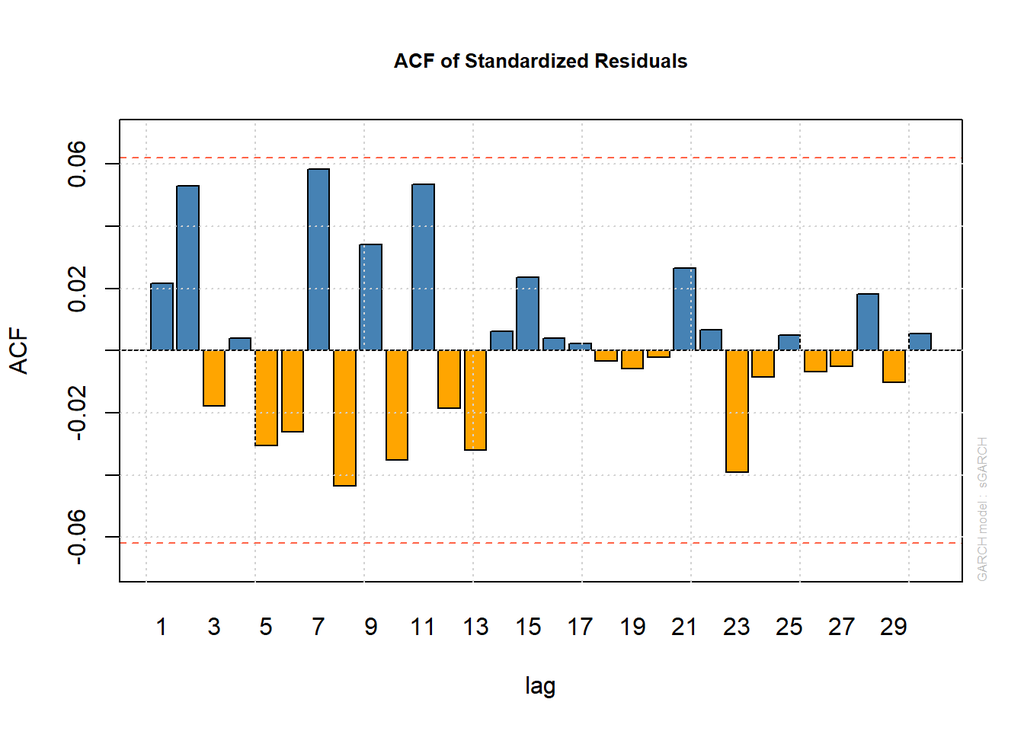

```r
plot_std_residuals(arma00garch12)
```

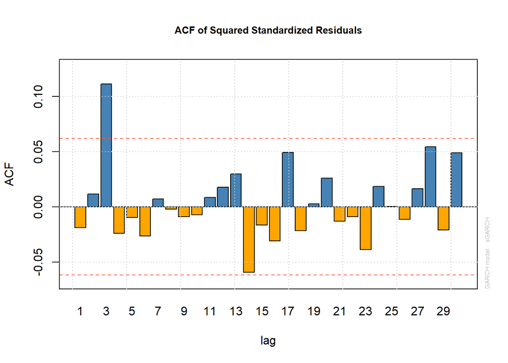

```r
plot_std_sq_residuals(arma00garch12)
```

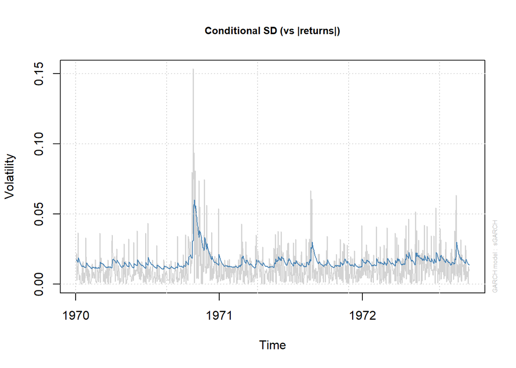

```r
plot_conditional_sd(arma00garch12)
```

#### Comment

- GARCH(2) is not significant and estimated to be zero.
- ACF of standardized residuals shows almost no autocorrelation.
- ACF of squared standardized residuals shows significant third lag.
- Both Ljung-Box test for standardized squared residuals and LM tests do not allow us to reject null-hypothesis of no autocorrelation of said residuals (except for LB 8th lag, but LM test shows no autocorrelation)

### ARMA(0,0)-GARCH(2,2)

```r
arma00garch22 <- fit_garch(insample_r$r, 0, 0, 2, 2)
arma00garch22
```

```
##
## *---------------------------------*
## *          GARCH Model Fit        *
## *---------------------------------*
##
## Conditional Variance Dynamics
## -----------------------------------
## GARCH Model  : sGARCH(2,2)
## Mean Model   : ARFIMA(0,0,0)
## Distribution : norm
##
## Optimal Parameters
## ------------------------------------
##         Estimate  Std. Error  t value Pr(>|t|)
## mu      0.001093    0.000455  2.40043 0.016376
## omega   0.000018    0.000006  2.88318 0.003937
## alpha1  0.059924    0.032013  1.87190 0.061220
## alpha2  0.058196    0.040635  1.43216 0.152097
## beta1   0.778681    0.276124  2.82004 0.004802
## beta2   0.037491    0.273421  0.13712 0.890938
##
## Robust Standard Errors:
##         Estimate  Std. Error  t value Pr(>|t|)
## mu      0.001093    0.000521 2.098543 0.035857
## omega   0.000018    0.000015 1.190733 0.233759
## alpha1  0.059924    0.043370 1.381695 0.167065
## alpha2  0.058196    0.053762 1.082467 0.279045
## beta1   0.778681    0.478202 1.628351 0.103451
## beta2   0.037491    0.515734 0.072694 0.942050
##
## LogLikelihood : 2761.398
##
## Information Criteria
## ------------------------------------
##
## Akaike       -5.5053
## Bayes        -5.4759
## Shibata      -5.5054
## Hannan-Quinn -5.4941
##
```

[output cut: 43 more lines]

```
## Negative Sign Bias   2.217 0.02682  **
## Positive Sign Bias   1.671 0.09509   *
## Joint Effect         8.592 0.03524  **
##
##
## Adjusted Pearson Goodness-of-Fit Test:
## ------------------------------------
##   group statistic p-value(g-1)
## 1    20     41.94   0.00180739
## 2    30     59.73   0.00066738
## 3    40     79.24   0.00014783
## 4    50     95.45   0.00007991
##
##
## Elapsed time : 0.4193981
```

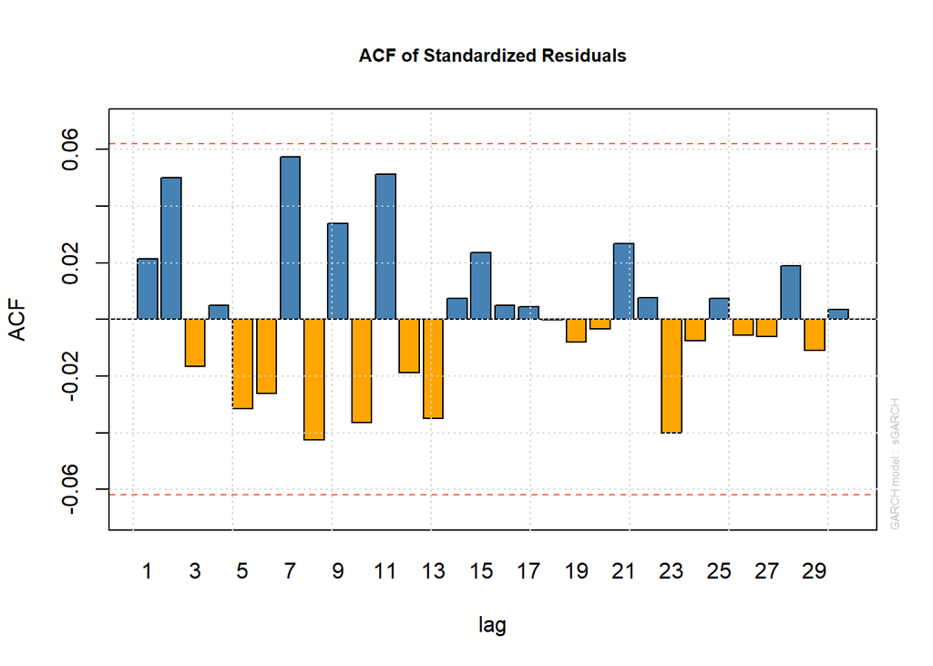

```r
plot_std_residuals(arma00garch22)
```

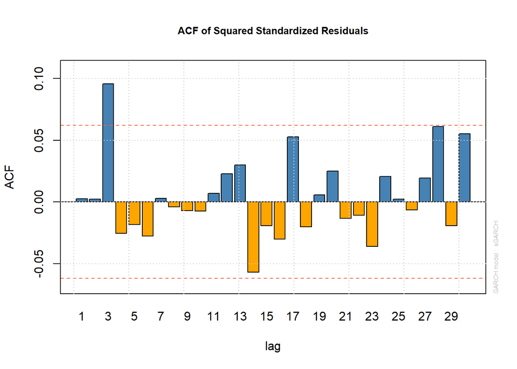

```r
plot_std_sq_residuals(arma00garch22)
```

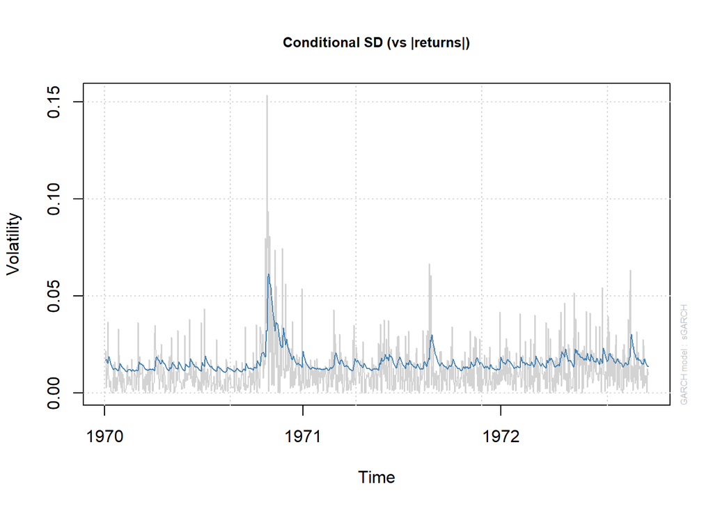

```r
plot_conditional_sd(arma00garch22)
```

#### Comment

- ARCH(1), ARCH(2) and GARCH(2) parameters are not significant. GARCH(2) is close to zero.
- ACF of standardized residuals shows no autocorrelation.
- ACF of squared standardized residuals shows significant third lag.
- Both Ljung-Box test for standardized squared residuals and LM tests do not allow us to reject null-hypothesis of no autocorrelation of said residuals.

### ARMA(0,0)-GARCH(3,3)

For the educational purposes let’s investigate higher orders of GARCH, although we are aware that these models are considered complex and redundant in practice.

```r
arma00garch33 <- fit_garch(insample_r$r, 0, 0, 3, 3)
arma00garch33
```

```
##
## *---------------------------------*
## *          GARCH Model Fit        *
## *---------------------------------*
##
## Conditional Variance Dynamics
## -----------------------------------
## GARCH Model  : sGARCH(3,3)
## Mean Model   : ARFIMA(0,0,0)
## Distribution : norm
##
## Optimal Parameters
## ------------------------------------
##         Estimate  Std. Error   t value Pr(>|t|)
## mu      0.001090    0.000453  2.404312 0.016203
## omega   0.000034    0.000012  2.765406 0.005685
## alpha1  0.049322    0.026992  1.827296 0.067655
## alpha2  0.073286    0.035043  2.091318 0.036500
## alpha3  0.094383    0.037624  2.508615 0.012121
## beta1   0.261041    0.141869  1.840011 0.065767
## beta2   0.000000    0.311093  0.000001 0.999999
## beta3   0.392128    0.035295 11.109995 0.000000
##
## Robust Standard Errors:
##         Estimate  Std. Error  t value Pr(>|t|)
## mu      0.001090    0.000497 2.193998 0.028236
## omega   0.000034    0.000016 2.078938 0.037623
## alpha1  0.049322    0.032762 1.505446 0.132209
## alpha2  0.073286    0.050553 1.449694 0.147144
## alpha3  0.094383    0.052387 1.801653 0.071600
## beta1   0.261041    0.232358 1.123443 0.261249
## beta2   0.000000    0.282935 0.000001 0.999999
## beta3   0.392128    0.185128 2.118142 0.034163
##
## LogLikelihood : 2762.999
##
## Information Criteria
## ------------------------------------
##
## Akaike       -5.5045
```

[output cut: 49 more lines]

```
## Negative Sign Bias   2.389 0.01710  **
## Positive Sign Bias   1.528 0.12684
## Joint Effect         8.814 0.03187  **
##
##
## Adjusted Pearson Goodness-of-Fit Test:
## ------------------------------------
##   group statistic p-value(g-1)
## 1    20     43.18   0.00122642
## 2    30     64.40   0.00016964
## 3    40     71.89   0.00104369
## 4    50     97.45   0.00004706
##
##
## Elapsed time : 0.8395281
```

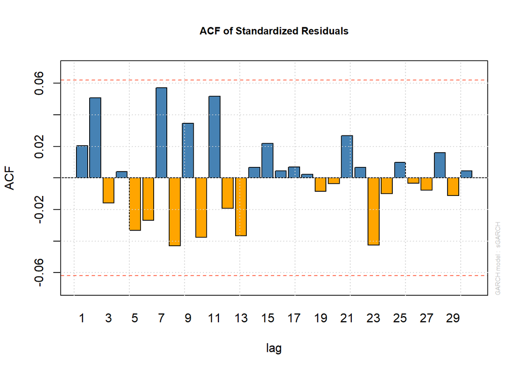

```r
plot_std_residuals(arma00garch33)
```

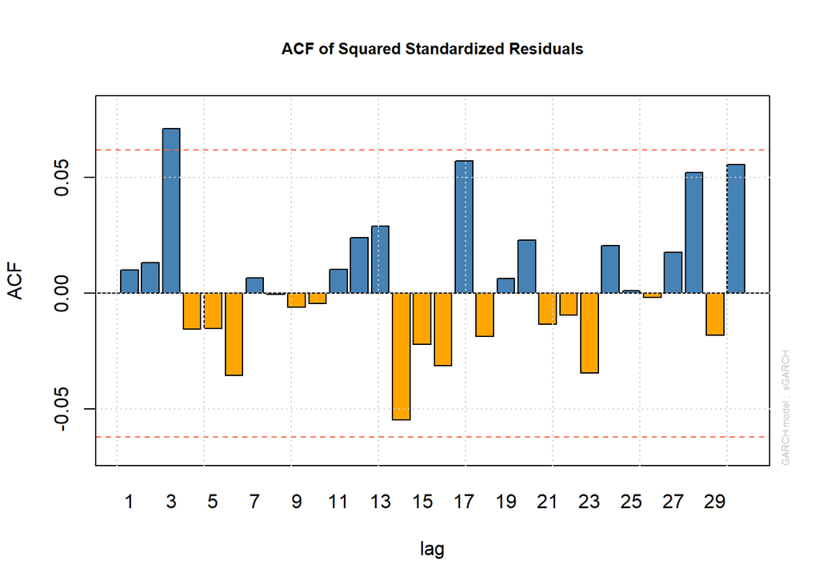

```r
plot_std_sq_residuals(arma00garch33)
```

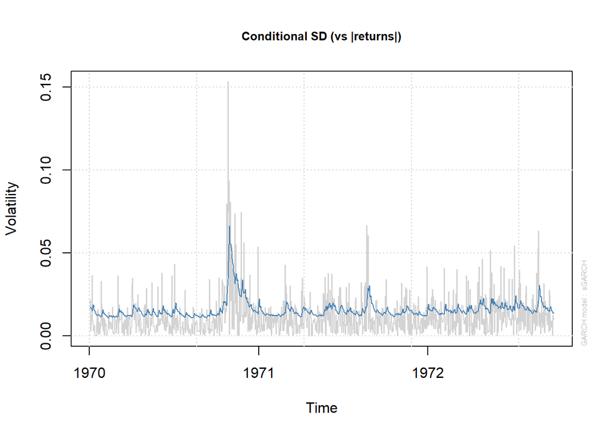

```r
plot_conditional_sd(arma00garch33)
```

#### Comment

- ARCH(1) and GARCH(2) parameters are not significant. GARCH(2) is even estimated to be zero.
- ACF of standardized residuals shows no autocorrelation.
- ACF of squared standardized residuals shows significant third lag.
- Both Ljung-Box test for standardized squared residuals and LM tests do not allow us to reject null-hypothesis of no autocorrelation of said residuals.

Perhaps, now we should move to altering mean equation to see the effects.

### ARMA(7,0)-GARCH(2,1)

```r
arma70garch21 <- fit_garch(insample_r$r, 7, 0, 2, 1)
arma70garch21
```

```
##
## *---------------------------------*
## *          GARCH Model Fit        *
## *---------------------------------*
##
## Conditional Variance Dynamics
## -----------------------------------
## GARCH Model  : sGARCH(2,1)
## Mean Model   : ARFIMA(7,0,0)
## Distribution : norm
##
## Optimal Parameters
## ------------------------------------
##         Estimate  Std. Error  t value Pr(>|t|)
## mu      0.001132    0.000483  2.34435 0.019060
## ar1     0.043141    0.034996  1.23274 0.217674
## ar2     0.038487    0.034158  1.12671 0.259864
## ar3    -0.046467    0.034485 -1.34746 0.177833
## ar4     0.009768    0.033714  0.28972 0.772030
## ar5    -0.023449    0.033153 -0.70729 0.479388
## ar6    -0.031726    0.032808 -0.96702 0.333535
## ar7     0.074065    0.032213  2.29924 0.021491
## omega   0.000018    0.000007  2.42914 0.015135
## alpha1  0.076289    0.036863  2.06955 0.038494
## alpha2  0.041880    0.049993  0.83771 0.402192
## beta1   0.814309    0.055025 14.79884 0.000000
##
## Robust Standard Errors:
##         Estimate  Std. Error  t value Pr(>|t|)
## mu      0.001132    0.000522  2.16979 0.030023
## ar1     0.043141    0.039119  1.10281 0.270110
## ar2     0.038487    0.033445  1.15074 0.249839
## ar3    -0.046467    0.042562 -1.09175 0.274942
## ar4     0.009768    0.030956  0.31553 0.752356
## ar5    -0.023449    0.026371 -0.88921 0.373893
## ar6    -0.031726    0.029123 -1.08938 0.275986
## ar7     0.074065    0.032059  2.31028 0.020873
## omega   0.000018    0.000012  1.45561 0.145501
## alpha1  0.076289    0.049332  1.54645 0.121996
## alpha2  0.041880    0.083789  0.49983 0.617196
```

[output cut: 61 more lines]

```
## Negative Sign Bias   2.002 0.04557  **
## Positive Sign Bias   1.659 0.09741   *
## Joint Effect         7.883 0.04849  **
##
##
## Adjusted Pearson Goodness-of-Fit Test:
## ------------------------------------
##   group statistic p-value(g-1)
## 1    20     38.94   0.00449660
## 2    30     57.45   0.00126778
## 3    40     77.48   0.00023921
## 4    50     98.15   0.00003902
##
##
## Elapsed time : 0.8852561
```

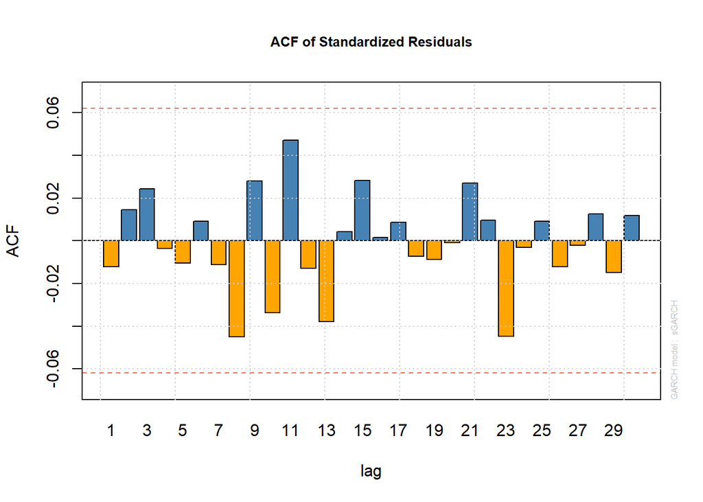

```r
plot_std_residuals(arma70garch21)
```

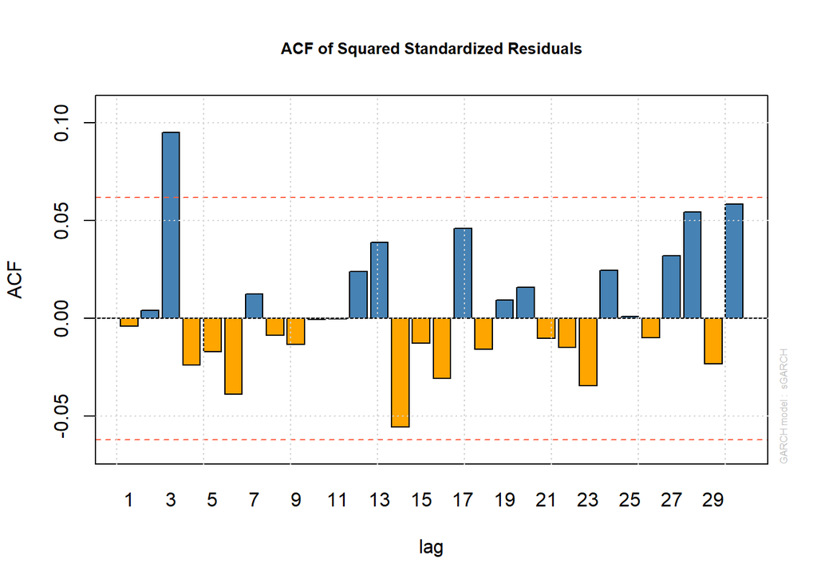

```r
plot_std_sq_residuals(arma70garch21)
```

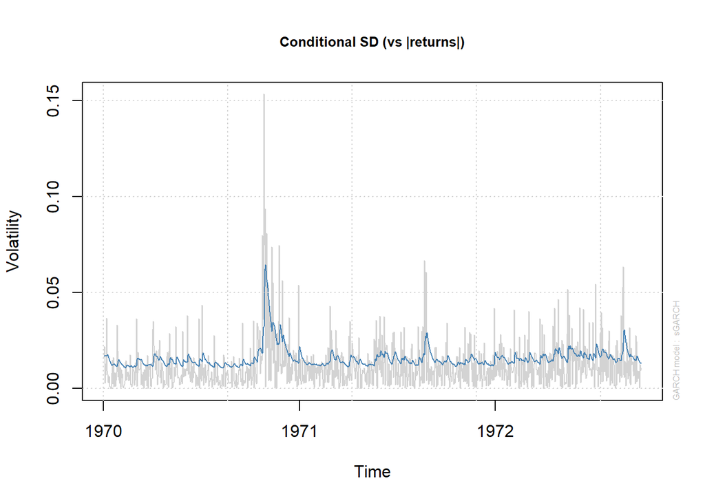

```r
plot_conditional_sd(arma70garch21)
```

#### Comment

- All AR lags except for the 7th are insignificant. ARCH(2) is also insignificant.
- ACF of standardized residuals shows no autocorrelation.
- ACF of squared standardized residuals shows significant third lag, as in all previous cases.
- Both Ljung-Box test for standardized squared residuals and LM tests do not allow us to reject null-hypothesis of no autocorrelation of said residuals.